# Project 1

## Step 1: Load the data and perform basic operations.

##### 1. Load the data in using pandas.

```python
import pandas as pd
actfile = '../data/act.csv'
satfile = '../data/sat.csv'
actData = pd.read_csv(actfile, index_col="Unnamed: 0")
satData = pd.read_csv(satfile, index_col="Unnamed: 0")
```

##### 2. Print the first ten rows of each dataframe.

```python
actData.head(10)
```

|  | State | Participation | English | Math | Reading | Science | Composite |
| --- | --- | --- | --- | --- | --- | --- | --- |
| 0 | National | 60% | 20.3 | 20.7 | 21.4 | 21.0 | 21.0 |
| 1 | Alabama | 100% | 18.9 | 18.4 | 19.7 | 19.4 | 19.2 |
| 2 | Alaska | 65% | 18.7 | 19.8 | 20.4 | 19.9 | 19.8 |
| 3 | Arizona | 62% | 18.6 | 19.8 | 20.1 | 19.8 | 19.7 |
| 4 | Arkansas | 100% | 18.9 | 19.0 | 19.7 | 19.5 | 19.4 |
| 5 | California | 31% | 22.5 | 22.7 | 23.1 | 22.2 | 22.8 |
| 6 | Colorado | 100% | 20.1 | 20.3 | 21.2 | 20.9 | 20.8 |
| 7 | Connecticut | 31% | 25.5 | 24.6 | 25.6 | 24.6 | 25.2 |
| 8 | Delaware | 18% | 24.1 | 23.4 | 24.8 | 23.6 | 24.1 |
| 9 | District of Columbia | 32% | 24.4 | 23.5 | 24.9 | 23.5 | 24.2 |

```python
satData.head(10)
```

|  | State | Participation | Evidence-Based Reading and Writing | Math | Total |
| --- | --- | --- | --- | --- | --- |
| 0 | Alabama | 5% | 593 | 572 | 1165 |
| 1 | Alaska | 38% | 547 | 533 | 1080 |
| 2 | Arizona | 30% | 563 | 553 | 1116 |
| 3 | Arkansas | 3% | 614 | 594 | 1208 |
| 4 | California | 53% | 531 | 524 | 1055 |
| 5 | Colorado | 11% | 606 | 595 | 1201 |
| 6 | Connecticut | 100% | 530 | 512 | 1041 |
| 7 | Delaware | 100% | 503 | 492 | 996 |
| 8 | District of Columbia | 100% | 482 | 468 | 950 |
| 9 | Florida | 83% | 520 | 497 | 1017 |

##### 3. Describe in words what each variable (column) is.

The erstwhile "Unnamed: 0" column was an apparent indexing column, which I co-opted to use as the index column. State lists each state/territory as a string. Participation shows the percentage of students in each state that take the given test (ACT/SAT). The ACT data also includes a "National" entry that appears to be a composite of each state's data. The SAT data does not have this.

In the ACT table, the four subject columns show scores for each section (English, Reading, Math, Science); the final Composite column shows the ACT-calculated Composite score. Each of these columns has a maximum possible value of 36, given the structure of the test. In the SAT table, there is a score for "Evidence-Based Reading and Writing" (a terribly over-wrought name), as well as for Math (both with a max of 800), and a Total column with a max of 1600.

##### 4. Does the data look complete? Are there any obvious issues with the observations?

The main issue I see with the observations is that the states that have high participation in one test have much lower participation in the other. This may correspond to different state rules about requiring students to take one test or the other in order to graduate.

Totals in the SAT table do not always match to the sum of the two subject areas, but this is probably a rounding error.

##### 5. Print the types of each column.

```python
actData.dtypes
```

```
State             object
Participation     object
English          float64
Math             float64
Reading          float64
Science          float64
Composite        float64
dtype: object
```

```python
satData.dtypes
```

```
State                                 object
Participation                         object
Evidence-Based Reading and Writing     int64
Math                                   int64
Total                                  int64
dtype: object
```

##### 6. Do any types need to be reassigned? If so, go ahead and do it.

Participation may be better manipulated as a float for analytical and plotting purposes; SAT scores might also be better suited to floats for analysis as well. They can be rounded effectively as floats, but can't easily add mathematical precision when they are integers.

```python
def percent2float(column):

    # removes the % sign from the string
    listed = [x.strip("%") for x in column]

    # coerce forces anything that may be "off" to a value of nan
    # divide by 100 to get percentage from 0 to 1
    newColumn = pd.to_numeric(listed,errors='coerce')/100
    return newColumn

actData["Participation"] = percent2float(actData["Participation"])
satData["Participation"] = percent2float(satData["Participation"])
```

```python
satData.head()
```

|  | State | Participation | Evidence-Based Reading and Writing | Math | Total |
| --- | --- | --- | --- | --- | --- |
| 0 | Alabama | 0.05 | 593 | 572 | 1165 |
| 1 | Alaska | 0.38 | 547 | 533 | 1080 |
| 2 | Arizona | 0.30 | 563 | 553 | 1116 |
| 3 | Arkansas | 0.03 | 614 | 594 | 1208 |
| 4 | California | 0.53 | 531 | 524 | 1055 |

##### 7. Create a dictionary for each column mapping the State to its respective value for that column. (For example, you should have three SAT dictionaries.)

```python
actEng = dict(zip(actData['State'],actData['English']))
actRead = dict(zip(actData['State'],actData['Reading']))
actMath = dict(zip(actData['State'],actData['Math']))
actSci = dict(zip(actData['State'],actData['Science']))
actComp = dict(zip(actData['State'],actData['Composite']))
satERW = dict(zip(satData['State'],satData['Evidence-Based Reading and Writing']))
satMath = dict(zip(satData['State'],satData['Math']))
satTot = dict(zip(satData['State'],satData['Total']))
```

##### 8. Create one dictionary where each key is the column name, and each value is an iterable (a list or a Pandas Series) of all the values in that column.

```python
actDict = {col:list(actData[col]) for col in actData.columns}
```

```python
satDict = {col:list(satData[col]) for col in satData.columns}
```

##### 9. Merge the dataframes on the state column.

```python
mergedSet = pd.merge(actData,satData,on="State")
```

##### 10. Change the names of the columns so you can distinguish between the SAT columns and the ACT columns.

```python
newCols = ["State","ACT Participation","ACT Eng","ACT Math","ACT Read","ACT Sci","ACT Comp","SAT Participation","SAT Read-Write","SAT Math","SAT Total"]
```

```python
mergedSet.columns = newCols
```

```python
mergedSet.head()
```

|  | State | ACT Participation | ACT Eng | ACT Math | ACT Read | ACT Sci | ACT Comp | SAT Participation | SAT Read-Write | SAT Math | SAT Total |
| --- | --- | --- | --- | --- | --- | --- | --- | --- | --- | --- | --- |
| 0 | Alabama | 1.00 | 18.9 | 18.4 | 19.7 | 19.4 | 19.2 | 0.05 | 593 | 572 | 1165 |
| 1 | Alaska | 0.65 | 18.7 | 19.8 | 20.4 | 19.9 | 19.8 | 0.38 | 547 | 533 | 1080 |
| 2 | Arizona | 0.62 | 18.6 | 19.8 | 20.1 | 19.8 | 19.7 | 0.30 | 563 | 553 | 1116 |
| 3 | Arkansas | 1.00 | 18.9 | 19.0 | 19.7 | 19.5 | 19.4 | 0.03 | 614 | 594 | 1208 |
| 4 | California | 0.31 | 22.5 | 22.7 | 23.1 | 22.2 | 22.8 | 0.53 | 531 | 524 | 1055 |

##### 11. Print the minimum and maximum of each numeric column in the data frame.

```python
# confirmation of ability to isolate min/max after using describe() -- credit to StackOverflow
```

```python
mergedSet.describe().loc[['min','max']]
```

|  | ACT Participation | ACT Eng | ACT Math | ACT Read | ACT Sci | ACT Comp | SAT Participation | SAT Read-Write | SAT Math | SAT Total |
| --- | --- | --- | --- | --- | --- | --- | --- | --- | --- | --- |
| min | 0.08 | 16.3 | 18.0 | 18.1 | 18.2 | 17.8 | 0.02 | 482.0 | 468.0 | 950.0 |
| max | 1.00 | 25.5 | 25.3 | 26.0 | 24.9 | 25.5 | 1.00 | 644.0 | 651.0 | 1295.0 |

##### 12. Write a function using only list comprehensions, no loops, to compute standard deviation. Using this function, calculate the standard deviation of each numeric column in both data sets. Add these to a list called `sd`.

$$\sigma = \sqrt{\frac{1}{n}\sum_{i=1}^n(x_i - \mu)}$$

```python
import numpy as np
def stand_dev(data):
    dataMean = np.mean(data)

    # the formula above isn't actually correct -- the individual differences in the sum need to be squared!!
    var = sum([(ii - dataMean) ** 2 for ii in data]) / len(data)
    return var ** 0.5
```

```python
columns = list(mergedSet.describe())
sd = ["Standard Deviation"]
for column in columns:
    newSD = stand_dev(mergedSet[column])
    sd.append(newSD)
```

## Step 2: Manipulate the dataframe

##### 13. Turn the list `sd` into a new observation in your dataset.

```python
# adds the Standard Deviation observation to the end of mergedSet
mergedSet.loc[len(mergedSet)] = sd
```

##### 14. Sort the dataframe by the values in a numeric column (e.g. observations descending by SAT participation rate)

```python
# segregate out the Standard Deviation observation for future analysis since it isn't a state
state_data = mergedSet[:-1]
state_data.sort_values(by="ACT Participation",ascending=False)
```

|  | State | ACT Participation | ACT Eng | ACT Math | ACT Read | ACT Sci | ACT Comp | SAT Participation | SAT Read-Write | SAT Math | SAT Total |
| --- | --- | --- | --- | --- | --- | --- | --- | --- | --- | --- | --- |
| 0 | Alabama | 1.00 | 18.9 | 18.4 | 19.7 | 19.4 | 19.2 | 0.05 | 593.0 | 572.0 | 1165.0 |
| 17 | Kentucky | 1.00 | 19.6 | 19.4 | 20.5 | 20.1 | 20.0 | 0.04 | 631.0 | 616.0 | 1247.0 |
| 49 | Wisconsin | 1.00 | 19.7 | 20.4 | 20.6 | 20.9 | 20.5 | 0.03 | 642.0 | 649.0 | 1291.0 |
| 44 | Utah | 1.00 | 19.5 | 19.9 | 20.8 | 20.6 | 20.3 | 0.03 | 624.0 | 614.0 | 1238.0 |
| 42 | Tennessee | 1.00 | 19.5 | 19.2 | 20.1 | 19.9 | 19.8 | 0.05 | 623.0 | 604.0 | 1228.0 |
| 40 | South Carolina | 1.00 | 17.5 | 18.6 | 19.1 | 18.9 | 18.7 | 0.50 | 543.0 | 521.0 | 1064.0 |
| 36 | Oklahoma | 1.00 | 18.5 | 18.8 | 20.1 | 19.6 | 19.4 | 0.07 | 530.0 | 517.0 | 1047.0 |
| 33 | North Carolina | 1.00 | 17.8 | 19.3 | 19.6 | 19.3 | 19.1 | 0.49 | 546.0 | 535.0 | 1081.0 |
| 28 | Nevada | 1.00 | 16.3 | 18.0 | 18.1 | 18.2 | 17.8 | 0.26 | 563.0 | 553.0 | 1116.0 |
| 26 | Montana | 1.00 | 19.0 | 20.2 | 21.0 | 20.5 | 20.3 | 0.10 | 605.0 | 591.0 | 1196.0 |
| 24 | Mississippi | 1.00 | 18.2 | 18.1 | 18.8 | 18.8 | 18.6 | 0.02 | 634.0 | 607.0 | 1242.0 |
| 23 | Minnesota | 1.00 | 20.4 | 21.5 | 21.8 | 21.6 | 21.5 | 0.03 | 644.0 | 651.0 | 1295.0 |
| 18 | Louisiana | 1.00 | 19.4 | 18.8 | 19.8 | 19.6 | 19.5 | 0.04 | 611.0 | 586.0 | 1198.0 |
| 25 | Missouri | 1.00 | 19.8 | 19.9 | 20.8 | 20.5 | 20.4 | 0.03 | 640.0 | 631.0 | 1271.0 |
| 50 | Wyoming | 1.00 | 19.4 | 19.8 | 20.8 | 20.6 | 20.2 | 0.03 | 626.0 | 604.0 | 1230.0 |
| 5 | Colorado | 1.00 | 20.1 | 20.3 | 21.2 | 20.9 | 20.8 | 0.11 | 606.0 | 595.0 | 1201.0 |
| 3 | Arkansas | 1.00 | 18.9 | 19.0 | 19.7 | 19.5 | 19.4 | 0.03 | 614.0 | 594.0 | 1208.0 |
| 34 | North Dakota | 0.98 | 19.0 | 20.4 | 20.5 | 20.6 | 20.3 | 0.02 | 635.0 | 621.0 | 1256.0 |
| 13 | Illinois | 0.93 | 21.0 | 21.2 | 21.6 | 21.3 | 21.4 | 0.09 | 559.0 | 556.0 | 1115.0 |
| 11 | Hawaii | 0.90 | 17.8 | 19.2 | 19.2 | 19.3 | 19.0 | 0.55 | 544.0 | 541.0 | 1085.0 |
| 27 | Nebraska | 0.84 | 20.9 | 20.9 | 21.9 | 21.5 | 21.4 | 0.03 | 629.0 | 625.0 | 1253.0 |
| 41 | South Dakota | 0.80 | 20.7 | 21.5 | 22.3 | 22.0 | 21.8 | 0.03 | 612.0 | 603.0 | 1216.0 |
| 35 | Ohio | 0.75 | 21.2 | 21.6 | 22.5 | 22.0 | 22.0 | 0.12 | 578.0 | 570.0 | 1149.0 |
| 9 | Florida | 0.73 | 19.0 | 19.4 | 21.0 | 19.4 | 19.8 | 0.83 | 520.0 | 497.0 | 1017.0 |
| 16 | Kansas | 0.73 | 21.1 | 21.3 | 22.3 | 21.7 | 21.7 | 0.04 | 632.0 | 628.0 | 1260.0 |
| 48 | West Virginia | 0.69 | 20.0 | 19.4 | 21.2 | 20.5 | 20.4 | 0.14 | 558.0 | 528.0 | 1086.0 |
| 15 | Iowa | 0.67 | 21.2 | 21.3 | 22.6 | 22.1 | 21.9 | 0.02 | 641.0 | 635.0 | 1275.0 |
| 31 | New Mexico | 0.66 | 18.6 | 19.4 | 20.4 | 20.0 | 19.7 | 0.11 | 577.0 | 561.0 | 1138.0 |
| 1 | Alaska | 0.65 | 18.7 | 19.8 | 20.4 | 19.9 | 19.8 | 0.38 | 547.0 | 533.0 | 1080.0 |
| 2 | Arizona | 0.62 | 18.6 | 19.8 | 20.1 | 19.8 | 19.7 | 0.30 | 563.0 | 553.0 | 1116.0 |
| 10 | Georgia | 0.55 | 21.0 | 20.9 | 22.0 | 21.3 | 21.4 | 0.61 | 535.0 | 515.0 | 1050.0 |
| 43 | Texas | 0.45 | 19.5 | 20.7 | 21.1 | 20.9 | 20.7 | 0.62 | 513.0 | 507.0 | 1020.0 |
| 37 | Oregon | 0.40 | 21.2 | 21.5 | 22.4 | 21.7 | 21.8 | 0.43 | 560.0 | 548.0 | 1108.0 |
| 12 | Idaho | 0.38 | 21.9 | 21.8 | 23.0 | 22.1 | 22.3 | 0.93 | 513.0 | 493.0 | 1005.0 |
| 14 | Indiana | 0.35 | 22.0 | 22.4 | 23.2 | 22.3 | 22.6 | 0.63 | 542.0 | 532.0 | 1074.0 |
| 30 | New Jersey | 0.34 | 23.8 | 23.8 | 24.1 | 23.2 | 23.9 | 0.70 | 530.0 | 526.0 | 1056.0 |
| 8 | District of Columbia | 0.32 | 24.4 | 23.5 | 24.9 | 23.5 | 24.2 | 1.00 | 482.0 | 468.0 | 950.0 |
| 6 | Connecticut | 0.31 | 25.5 | 24.6 | 25.6 | 24.6 | 25.2 | 1.00 | 530.0 | 512.0 | 1041.0 |
| 4 | California | 0.31 | 22.5 | 22.7 | 23.1 | 22.2 | 22.8 | 0.53 | 531.0 | 524.0 | 1055.0 |
| 32 | New York | 0.31 | 23.8 | 24.0 | 24.6 | 23.9 | 24.2 | 0.67 | 528.0 | 523.0 | 1052.0 |
| 22 | Michigan | 0.29 | 24.1 | 23.7 | 24.5 | 23.8 | 24.1 | 1.00 | 509.0 | 495.0 | 1005.0 |
| 21 | Massachusetts | 0.29 | 25.4 | 25.3 | 25.9 | 24.7 | 25.4 | 0.76 | 555.0 | 551.0 | 1107.0 |
| 45 | Vermont | 0.29 | 23.3 | 23.1 | 24.4 | 23.2 | 23.6 | 0.60 | 562.0 | 551.0 | 1114.0 |
| 46 | Virginia | 0.29 | 23.5 | 23.3 | 24.6 | 23.5 | 23.8 | 0.65 | 561.0 | 541.0 | 1102.0 |
| 47 | Washington | 0.29 | 20.9 | 21.9 | 22.1 | 22.0 | 21.9 | 0.64 | 541.0 | 534.0 | 1075.0 |
| 20 | Maryland | 0.28 | 23.3 | 23.1 | 24.2 | 23.2 | 23.6 | 0.69 | 536.0 | 524.0 | 1060.0 |
| 38 | Pennsylvania | 0.23 | 23.4 | 23.4 | 24.2 | 23.3 | 23.7 | 0.65 | 540.0 | 531.0 | 1071.0 |
| 39 | Rhode Island | 0.21 | 24.0 | 23.3 | 24.7 | 23.4 | 24.0 | 0.71 | 539.0 | 524.0 | 1062.0 |
| 7 | Delaware | 0.18 | 24.1 | 23.4 | 24.8 | 23.6 | 24.1 | 1.00 | 503.0 | 492.0 | 996.0 |
| 29 | New Hampshire | 0.18 | 25.4 | 25.1 | 26.0 | 24.9 | 25.5 | 0.96 | 532.0 | 520.0 | 1052.0 |
| 19 | Maine | 0.08 | 24.2 | 24.0 | 24.8 | 23.7 | 24.3 | 0.95 | 513.0 | 499.0 | 1012.0 |

##### 15. Use a boolean filter to display only observations with a score above a certain threshold (e.g. only states with a participation rate above 50%)

```python
state_data[state_data["SAT Math"] >= 550]
```

|  | State | ACT Participation | ACT Eng | ACT Math | ACT Read | ACT Sci | ACT Comp | SAT Participation | SAT Read-Write | SAT Math | SAT Total |
| --- | --- | --- | --- | --- | --- | --- | --- | --- | --- | --- | --- |
| 0 | Alabama | 1.00 | 18.9 | 18.4 | 19.7 | 19.4 | 19.2 | 0.05 | 593.0 | 572.0 | 1165.0 |
| 2 | Arizona | 0.62 | 18.6 | 19.8 | 20.1 | 19.8 | 19.7 | 0.30 | 563.0 | 553.0 | 1116.0 |
| 3 | Arkansas | 1.00 | 18.9 | 19.0 | 19.7 | 19.5 | 19.4 | 0.03 | 614.0 | 594.0 | 1208.0 |
| 5 | Colorado | 1.00 | 20.1 | 20.3 | 21.2 | 20.9 | 20.8 | 0.11 | 606.0 | 595.0 | 1201.0 |
| 13 | Illinois | 0.93 | 21.0 | 21.2 | 21.6 | 21.3 | 21.4 | 0.09 | 559.0 | 556.0 | 1115.0 |
| 15 | Iowa | 0.67 | 21.2 | 21.3 | 22.6 | 22.1 | 21.9 | 0.02 | 641.0 | 635.0 | 1275.0 |
| 16 | Kansas | 0.73 | 21.1 | 21.3 | 22.3 | 21.7 | 21.7 | 0.04 | 632.0 | 628.0 | 1260.0 |
| 17 | Kentucky | 1.00 | 19.6 | 19.4 | 20.5 | 20.1 | 20.0 | 0.04 | 631.0 | 616.0 | 1247.0 |
| 18 | Louisiana | 1.00 | 19.4 | 18.8 | 19.8 | 19.6 | 19.5 | 0.04 | 611.0 | 586.0 | 1198.0 |
| 21 | Massachusetts | 0.29 | 25.4 | 25.3 | 25.9 | 24.7 | 25.4 | 0.76 | 555.0 | 551.0 | 1107.0 |
| 23 | Minnesota | 1.00 | 20.4 | 21.5 | 21.8 | 21.6 | 21.5 | 0.03 | 644.0 | 651.0 | 1295.0 |
| 24 | Mississippi | 1.00 | 18.2 | 18.1 | 18.8 | 18.8 | 18.6 | 0.02 | 634.0 | 607.0 | 1242.0 |
| 25 | Missouri | 1.00 | 19.8 | 19.9 | 20.8 | 20.5 | 20.4 | 0.03 | 640.0 | 631.0 | 1271.0 |
| 26 | Montana | 1.00 | 19.0 | 20.2 | 21.0 | 20.5 | 20.3 | 0.10 | 605.0 | 591.0 | 1196.0 |
| 27 | Nebraska | 0.84 | 20.9 | 20.9 | 21.9 | 21.5 | 21.4 | 0.03 | 629.0 | 625.0 | 1253.0 |
| 28 | Nevada | 1.00 | 16.3 | 18.0 | 18.1 | 18.2 | 17.8 | 0.26 | 563.0 | 553.0 | 1116.0 |
| 31 | New Mexico | 0.66 | 18.6 | 19.4 | 20.4 | 20.0 | 19.7 | 0.11 | 577.0 | 561.0 | 1138.0 |
| 34 | North Dakota | 0.98 | 19.0 | 20.4 | 20.5 | 20.6 | 20.3 | 0.02 | 635.0 | 621.0 | 1256.0 |
| 35 | Ohio | 0.75 | 21.2 | 21.6 | 22.5 | 22.0 | 22.0 | 0.12 | 578.0 | 570.0 | 1149.0 |
| 41 | South Dakota | 0.80 | 20.7 | 21.5 | 22.3 | 22.0 | 21.8 | 0.03 | 612.0 | 603.0 | 1216.0 |
| 42 | Tennessee | 1.00 | 19.5 | 19.2 | 20.1 | 19.9 | 19.8 | 0.05 | 623.0 | 604.0 | 1228.0 |
| 44 | Utah | 1.00 | 19.5 | 19.9 | 20.8 | 20.6 | 20.3 | 0.03 | 624.0 | 614.0 | 1238.0 |
| 45 | Vermont | 0.29 | 23.3 | 23.1 | 24.4 | 23.2 | 23.6 | 0.60 | 562.0 | 551.0 | 1114.0 |
| 49 | Wisconsin | 1.00 | 19.7 | 20.4 | 20.6 | 20.9 | 20.5 | 0.03 | 642.0 | 649.0 | 1291.0 |
| 50 | Wyoming | 1.00 | 19.4 | 19.8 | 20.8 | 20.6 | 20.2 | 0.03 | 626.0 | 604.0 | 1230.0 |

```python
state_data[state_data["SAT Participation"] < 0.1]
```

|  | State | ACT Participation | ACT Eng | ACT Math | ACT Read | ACT Sci | ACT Comp | SAT Participation | SAT Read-Write | SAT Math | SAT Total |
| --- | --- | --- | --- | --- | --- | --- | --- | --- | --- | --- | --- |
| 0 | Alabama | 1.00 | 18.9 | 18.4 | 19.7 | 19.4 | 19.2 | 0.05 | 593.0 | 572.0 | 1165.0 |
| 3 | Arkansas | 1.00 | 18.9 | 19.0 | 19.7 | 19.5 | 19.4 | 0.03 | 614.0 | 594.0 | 1208.0 |
| 13 | Illinois | 0.93 | 21.0 | 21.2 | 21.6 | 21.3 | 21.4 | 0.09 | 559.0 | 556.0 | 1115.0 |
| 15 | Iowa | 0.67 | 21.2 | 21.3 | 22.6 | 22.1 | 21.9 | 0.02 | 641.0 | 635.0 | 1275.0 |
| 16 | Kansas | 0.73 | 21.1 | 21.3 | 22.3 | 21.7 | 21.7 | 0.04 | 632.0 | 628.0 | 1260.0 |
| 17 | Kentucky | 1.00 | 19.6 | 19.4 | 20.5 | 20.1 | 20.0 | 0.04 | 631.0 | 616.0 | 1247.0 |
| 18 | Louisiana | 1.00 | 19.4 | 18.8 | 19.8 | 19.6 | 19.5 | 0.04 | 611.0 | 586.0 | 1198.0 |
| 23 | Minnesota | 1.00 | 20.4 | 21.5 | 21.8 | 21.6 | 21.5 | 0.03 | 644.0 | 651.0 | 1295.0 |
| 24 | Mississippi | 1.00 | 18.2 | 18.1 | 18.8 | 18.8 | 18.6 | 0.02 | 634.0 | 607.0 | 1242.0 |
| 25 | Missouri | 1.00 | 19.8 | 19.9 | 20.8 | 20.5 | 20.4 | 0.03 | 640.0 | 631.0 | 1271.0 |
| 27 | Nebraska | 0.84 | 20.9 | 20.9 | 21.9 | 21.5 | 21.4 | 0.03 | 629.0 | 625.0 | 1253.0 |
| 34 | North Dakota | 0.98 | 19.0 | 20.4 | 20.5 | 20.6 | 20.3 | 0.02 | 635.0 | 621.0 | 1256.0 |
| 36 | Oklahoma | 1.00 | 18.5 | 18.8 | 20.1 | 19.6 | 19.4 | 0.07 | 530.0 | 517.0 | 1047.0 |
| 41 | South Dakota | 0.80 | 20.7 | 21.5 | 22.3 | 22.0 | 21.8 | 0.03 | 612.0 | 603.0 | 1216.0 |
| 42 | Tennessee | 1.00 | 19.5 | 19.2 | 20.1 | 19.9 | 19.8 | 0.05 | 623.0 | 604.0 | 1228.0 |
| 44 | Utah | 1.00 | 19.5 | 19.9 | 20.8 | 20.6 | 20.3 | 0.03 | 624.0 | 614.0 | 1238.0 |
| 49 | Wisconsin | 1.00 | 19.7 | 20.4 | 20.6 | 20.9 | 20.5 | 0.03 | 642.0 | 649.0 | 1291.0 |
| 50 | Wyoming | 1.00 | 19.4 | 19.8 | 20.8 | 20.6 | 20.2 | 0.03 | 626.0 | 604.0 | 1230.0 |

## Step 3: Visualize the data

##### 16. Using MatPlotLib and PyPlot, plot the distribution of the Rate columns for both SAT and ACT using histograms. (You should have two histograms. You might find [this link](https://matplotlib.org/users/pyplot_tutorial.html#working-with-multiple-figures-and-axes) helpful in organizing one plot above the other.)

```python
import matplotlib.pyplot as plt
plt.rcParams['savefig.dpi'] = 500
import seaborn as sns
```

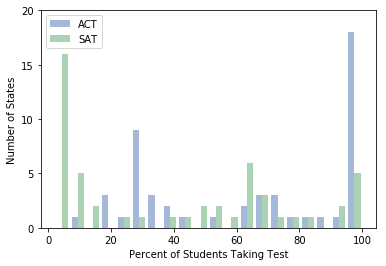

```python
fig31 = plt.figure(31)
ax31 = plt.subplot(111)
plt.title("")
#plt.style.use("seaborn-deep")
act_p = state_data["ACT Participation"]*100
sat_p = state_data["SAT Participation"]*100

# stack arrays to plot them together on one histogram
plotdata = np.vstack([act_p,sat_p]).T
_ = plt.hist(plotdata,bins=20,alpha=0.5,label=['ACT','SAT'])
_ = plt.xlabel("Percent of Students Taking Test")
_ = plt.ylabel("Number of States")
_ = ax31.yaxis.set(ticks=range(0,21,5))
_ = plt.legend(loc='best')
#fig31.subplots_adjust(hspace=0.3)
plt.savefig('act_vs_sat.png')
plt.show()
```

##### 17. Plot the Math(s) distributions from both data sets.

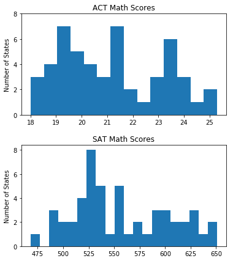

```python
fig32 = plt.figure(32)
ax1_32 = plt.subplot(211)
_ = plt.hist(state_data["ACT Math"],bins=14)
_ = plt.title("ACT Math Scores")
_ = plt.ylabel("Number of States")
_ = ax1_32.yaxis.set(ticks=range(0,9,2))
ax2_32 = plt.subplot(212)
_ = plt.hist(state_data["SAT Math"],bins=20)
_ = plt.title("SAT Math Scores")
_ = plt.ylabel("Number of States")
_ = ax2_32.yaxis.set(ticks=range(0,9,2))
fig32.set_figheight(7)
fig32.subplots_adjust(hspace=0.3)
plt.show()
```

##### 18. Plot the Verbal distributions from both data sets.

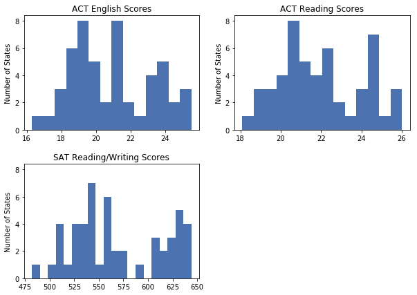

```python
fig33 = plt.figure(33)
ax1_33 = plt.subplot(221)
_ = plt.hist(state_data["ACT Eng"],bins=14)
_ = plt.title("ACT English Scores")
_ = plt.ylabel("Number of States")
_ = ax1_33.yaxis.set(ticks=range(0,9,2))
ax2_33 = plt.subplot(222,sharey=ax1_33)
_ = plt.hist(state_data["ACT Read"],bins=14)
_ = plt.title("ACT Reading Scores")
_ = plt.ylabel("Number of States")
ax3_33 = plt.subplot(223,sharey=ax1_33)
_ = plt.hist(state_data["SAT Read-Write"],bins=20)
_ = plt.title("SAT Reading/Writing Scores")
_ = plt.ylabel("Number of States")
fig33.set_figheight(7)
fig33.set_figwidth(10)
fig33.subplots_adjust(hspace=0.3)
plt.show()
```

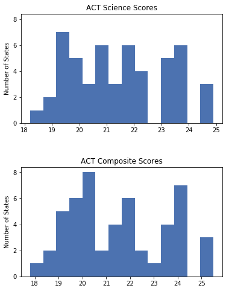

```python
fig34 = plt.figure(34)
ax1_34 = plt.subplot(211)
_ = plt.hist(state_data["ACT Sci"],bins=14)
_ = plt.title("ACT Science Scores")
_ = plt.ylabel("Number of States")
_ = ax1_34.yaxis.set(ticks=range(0,9,2))
ax2_34 = plt.subplot(212,sharey=ax1_34)
_ = plt.hist(state_data["ACT Comp"],bins=14)
_ = plt.title("ACT Composite Scores")
_ = plt.ylabel("Number of States")
fig34.set_figheight(8)
fig34.subplots_adjust(hspace=0.4)
plt.show()
```

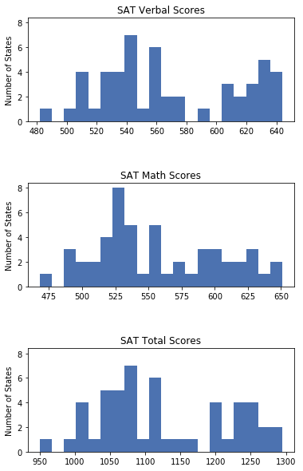

```python
fig35 = plt.figure(35)
ax1_35 = plt.subplot(311)
_ = plt.hist(state_data["SAT Read-Write"],bins=20)
_ = plt.title("SAT Verbal Scores")
_ = plt.ylabel("Number of States")
_ = ax1_35.yaxis.set(ticks=range(0,9,2))
ax2_35 = plt.subplot(312,sharey=ax1_35)
_ = plt.hist(state_data["SAT Math"],bins=20)
_ = plt.title("SAT Math Scores")
_ = plt.ylabel("Number of States")
ax3_35 = plt.subplot(313,sharey=ax1_35)
_ = plt.hist(state_data["SAT Total"],bins=20)
_ = plt.title("SAT Total Scores")
_ = plt.ylabel("Number of States")
fig35.set_figheight(10)
fig35.subplots_adjust(hspace=0.6)
plt.show()
```

##### 19. When we make assumptions about how data are distributed, what is the most common assumption?

We often assume that the data belongs to a normal distribution and can be modeled as such.

##### 20. Does this assumption hold true for any of our columns? Which?

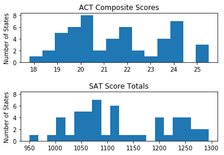

```python
fig4 = plt.figure(4)
ax1_4 = plt.subplot(211)
_ = plt.hist(state_data["ACT Comp"],bins=14)
_ = plt.title("ACT Composite Scores")
_ = plt.ylabel("Number of States")
_ = ax1_4.yaxis.set(ticks=range(0,9,2))
ax2_4 = plt.subplot(212,sharey=ax1_4)
_ = plt.hist(state_data["SAT Total"],bins=20)
_ = plt.title("SAT Score Totals")
_ = plt.ylabel("Number of States")
fig4.subplots_adjust(hspace=0.6)
plt.show()
```

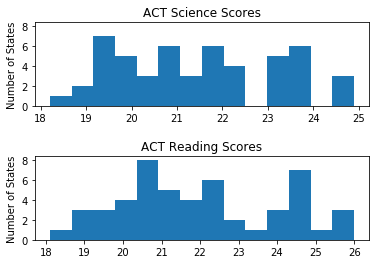

```python
fig5 = plt.figure(5)
ax1_5 = plt.subplot(211)
_ = plt.hist(state_data["ACT Sci"],bins=14)
_ = plt.title("ACT Science Scores")
_ = plt.ylabel("Number of States")
_ = ax1_5.yaxis.set(ticks=range(0,9,2))
ax2_5 = plt.subplot(212,sharey=ax1_5)
_ = plt.hist(state_data["ACT Read"],bins=14)
_ = plt.title("ACT Reading Scores")
_ = plt.ylabel("Number of States")
fig5.subplots_adjust(hspace=0.6)
plt.show()
```

##### 21. Plot some scatterplots examining relationships between all variables.

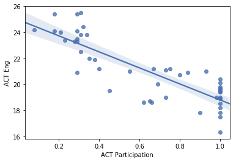

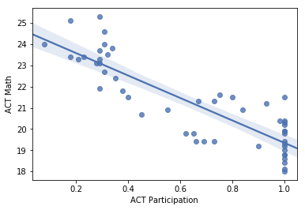

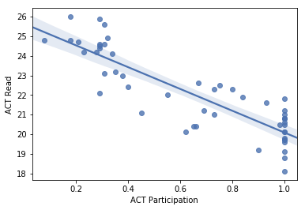

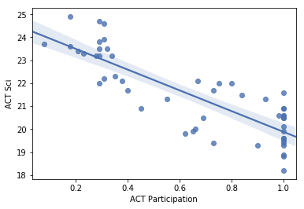

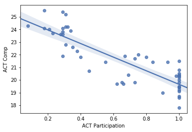

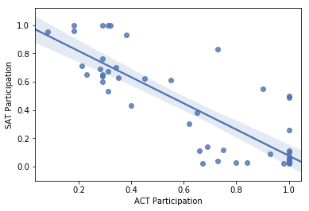

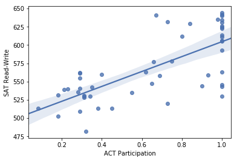

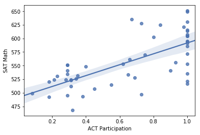

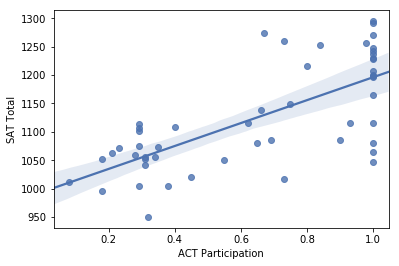

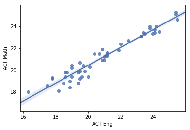

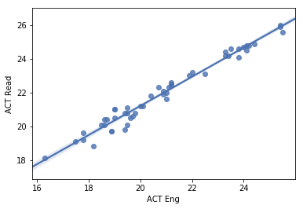

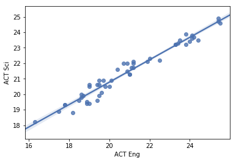

[33 more figures not shown]

```python
def plot_relationships(data):

    # gives the list of numerical columns in the state_data dataframe
    columns = list(data.describe())

    # this is an exhaustive relationship axis iterator
    # the while loop will run until the columns list is empty
    # xdata is the first-indexed entry in columns and it is "popped" out of the list
    # the for loop then iterates through the rest of the remaining columns
    # each variable relationship is plotted on a seaborn regression plot
    # each plot is then saved with its two compared statistics as the file name (when uncommented!)
    # credit to Chris Messier for the loop and discussion of its mechanism
    while columns:
        xdata = columns.pop(0)
        for ii in columns:
            sns.regplot(data[xdata],data[ii])
            title = xdata+ii+".png"
            #plt.savefig(title)
            plt.show()

plot_relationships(state_data)
```

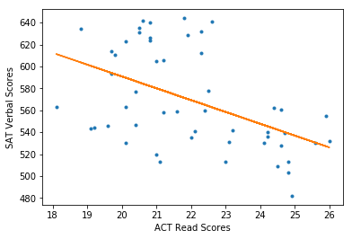

```python
fig16 = plt.figure(16)
_ = plt.plot(state_data["ACT Read"],state_data["SAT Read-Write"],marker='.',linestyle="none")
_ = plt.xlabel("ACT Read Scores")
_ = plt.ylabel("SAT Verbal Scores")
xx = state_data["ACT Read"]
m,b = np.polyfit(xx,state_data["SAT Read-Write"],1)
plt.plot(xx,m*xx+b)
#plt.savefig("act_reading_vs_sat_verbal.png")
plt.show()
```

##### 22. Are there any interesting relationships to note?

Scores in a state where the given test is not required / has a low participation tend to be higher than those where the test has the highest participation.

In particular, note the SAT Math and Verbal scores. States with SAT participation rates < 20% tend to have at least a 25-point higher score than states with SAT participation rates above 80%.

Each ACT component score correlated strongly with the ACT composite score, as did SAT component scores to the total. ACT and SAT cross-examination did not yield strong relationships either way, but there appears to be a negative correlation between the (a) ACT Math and SAT Math scores, (b) ACT English and SAT Verbal, *and* (c) ACT Reading and SAT Verbal that are worth exploring.

##### 23. Create box plots for each variable.

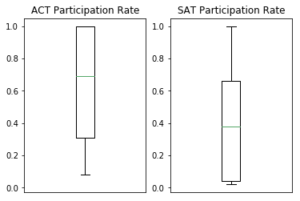

```python
bp1 = plt.figure(20)
ax20_1 = plt.subplot(121)
_ = plt.boxplot(state_data["ACT Participation"],sym="",whis=1)
_ = plt.title("ACT Participation Rate")
_ = ax20_1.yaxis.set(ticks=[0,0.2,0.4,0.6,0.8,1.0])
_ = plt.xticks([])

# Chris M. clued me in to the sharey method, which eliminated many extra lines of axis configuration!
ax20_2 = plt.subplot(122,sharey=ax20_1)
_ = plt.boxplot(state_data["SAT Participation"],sym="",whis=1)
_ = plt.title("SAT Participation Rate")
_ = plt.xticks([])
plt.show()
```

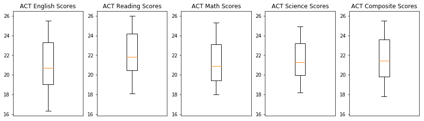

```python
bp2 = plt.figure(21)
ax21_1 = plt.subplot(151)
_ = plt.boxplot(state_data["ACT Eng"],sym="",whis=1)
_ = plt.title("ACT English Scores")
_ = ax21_1.yaxis.set(ticks=range(16,29,2))
_ = plt.xticks([])
ax21_2 = plt.subplot(152,sharey=ax21_1)
_ = plt.boxplot(state_data["ACT Read"],sym="",whis=1)
_ = plt.title("ACT Reading Scores")
_ = plt.xticks([])
ax21_3 = plt.subplot(153,sharey=ax21_1)
_ = plt.boxplot(state_data["ACT Math"],sym="",whis=1)
_ = plt.title("ACT Math Scores")
_ = plt.xticks([])
ax21_4 = plt.subplot(154,sharey=ax21_1)
_ = plt.boxplot(state_data["ACT Sci"],sym="",whis=1)
_ = plt.title("ACT Science Scores")
_ = plt.xticks([])
ax21_5 = plt.subplot(155,sharey=ax21_1)
_ = plt.boxplot(state_data["ACT Comp"],sym="",whis=1)
_ = plt.title("ACT Composite Scores")
_ = plt.xticks([])
bp2.set_figwidth(15)
plt.show()
```

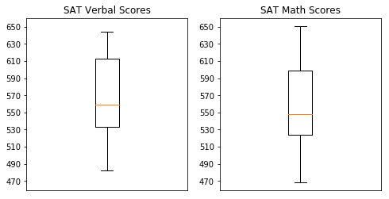

```python
bp3 = plt.figure(22)
ax22_1 = plt.subplot(121)
_ = plt.boxplot(state_data["SAT Read-Write"],sym="",whis=1)
_ = plt.title("SAT Verbal Scores")
_ = ax22_1.yaxis.set(ticks=range(450,670,20))
_ = plt.xticks([])
ax22_2 = plt.subplot(122, sharey=ax22_1)
_ = plt.boxplot(state_data["SAT Math"],sym="",whis=1)
_ = plt.title("SAT Math Scores")
_ = plt.xticks([])

bp3.set_figwidth(8)
plt.show()
```

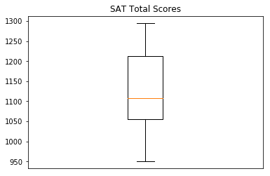

```python
bp4 = plt.figure(23)
_ = plt.boxplot(state_data["SAT Total"],sym="",whis=1)
_ = plt.title("SAT Total Scores")
# _ = ax21_1.yaxis.set(ticks=range(16,29,2))
_ = plt.xticks([])
plt.show()
```

##### BONUS: Using Tableau, create a heat map for each variable using a map of the US.